Please fill out the information of your group!

[output not shown]

## 344.105/6/7 UE: Natural Language Processing (WS2023/24)

# Assignment 2

## Getting to Know Word Embedding!

**Terms of Use**  
This material is prepared for educational purposes at the Johannes Kepler University (JKU) Linz, and is exclusively provided to the registered students of the mentioned course at JKU. It is strictly forbidden to distribute the current file, the contents of the assignment, and its solution. The use or reproduction of this manuscript is only allowed for educational purposes in non-profit organizations, while in this case, the explicit prior acceptance of the author(s) is required.

**Authors:** Navid Rekab-saz, Oleg Lesota

## Table of contents

General Guidelines

Task A: Words Similarity and Nearest Neighbors (15 points)

Task B: Document Classification with Word Embedding (15 points)

Task C: Classification with sent2vec Document Embeddings (2 extra point)

References

## General Guidelines

### Assignment objective

The aim of this assignment is to get familiarized with using word embedding (WE) models in practice. The assignment in total has **30 points**; it also offers **2 extra points** which can cover any missing point.

This Notebook encompasses all aspects of the assignment, namely the descriptions of tasks as well as your solutions and reports. Feel free to add any required cell for solutions. The cells can contain code, reports, charts, tables, or any other material, required for the assignment. Feel free to provide the solutions in an interactive and visual way!

Please discuss any unclear point in the assignment in the provided forum in MOODLE. It is also encouraged to provide answers to your peer's questions. However when submitting a post, keep in mind to avoid providing solutions. Please let the tutor(s) know shall you find any error or unclarity in the assignment.

### Libraries & Dataset

The assignment should be implemented with recent versions of `Python` (>3.7). Any standard Python library can be used, so far that the library is free and can be simply installed using `pip` or `conda`. Examples of potentially useful libraries are `scikit-learn`, `numpy`, `scipy`, `gensim`, `nltk`, `spaCy`, and `AllenNLP`. Use the latest stable version of each library.

To conduct the experiments, we use a subset of the `HumSet` dataset [1] (https://blog.thedeep.io/humset/). `HumSet` is created by the DEEP (https://www.thedeep.io) project – an open source platform which aims to facilitate processing of textual data for international humanitarian response organizations. The platform enables the classification of text excerpts, extracted from news and reports into a set of domain specific classes. The provided dataset contains the classes (labels) referring to the humanitarian sectors like agriculture, health, and protection. The dataset contains an overall number of 17,301 data points.

Download the dataset from the Moodle page of the course.

the provided zip file consists of the following files:

- `thedeep.subset.train.txt`: Train set in csv format with three fields: sentence_id, text, and label.
- `thedeep.subset.validation.txt`: Validation set in csv format with three fields: sentence_id, text, and label.
- `thedeep.subset.test.txt`: Test set in csv format with three fields: sentence_id, text, and label.
- `thedeep.subset.label.txt`: Captions of the labels.
- `thedeep.ToU.txt`: Terms of use of the dataset.

[1] HumSet: Dataset of Multilingual Information Extraction and Classification for Humanitarian Crises Response *Selim Fekih, Nicolo' Tamagnone, Benjamin Minixhofer, Ranjan Shrestha, Ximena Contla, Ewan Oglethorpe and Navid Rekabsaz.* In Findings of the 2022 Conference on Empirical Methods in Natural Language Processing (Findings of EMNLP), December 2022.

### Submission

Each group should submit the following two files:

- One Jupyter Notebook file (`.ipynb`), containing all the code, results, visualizations, etc. **In the submitted Notebook, all the results and visualizations should already be present, and can be observed simply by loading the Notebook in a browser.** The Notebook must be self-contained, meaning that (if necessary) one can run all the cells from top to bottom without any error. Do not forget to put in your names and student numbers in the first cell of the Notebook.
- The HTML file (`.html`) achieved from exporting the Jupyter Notebook to HTML (Download As HTML).

You do not need to include the data files in the submission.

## Task A: Words Similarity and Nearest Neighbors (15 points)

**Loading a word embedding (WE) model (1 points).** Download a pre-trained word embedding model such as word2vec (https://code.google.com/archive/p/word2vec/) or GloVe (https://nlp.stanford.edu/projects/glove/). You can load the downloaded vectors into arrays, or use libraries such as `gensim` to download and process the vectors.

**Calculating word-to-word similarities (4 points).** Select 5 arbitrary words from 5 different topics like objects, science disciplines, verbs, adjectives, animals, etc. Let us refer to these words as *source words*. For each source word, calculate its cosine similarities to 6 target words. The target words of each source word are also selected by you and should cover various levels of semantic relations – according to your linguistic judgement – to the source word, namely from highly-related to not related at all. Organize the target words in tables, such that the target words of each source word are sorted from the highest to the lowest relevance (according to your judgement). Consider the following points:

- **Implementation (2/4 points):** Implement cosine similarity as a function that takes two vectors and returns the similarity score. Implement cosine by yourself and do NOT use the provided functionalities of any library.
- **Reporting and observations (2/4 points):** Report the calculated similarities side by side with your word-to-word semantic relevance judgements in tables. Compare the results and report your observations.

**Calculating nearest neighbors (10 points).** For the 5 source words, retrieve the $k=10$ nearest neighbors using the word embedding model, namely the words with the highest similarities to the source word. Consider the following points:

- **Overall implementation (3/10 points):** your implemented function takes a source vector, a set of target vectors, and the $k$ parameter, and returns the $k$ nearest neighbors and their similarity scores. Implement nearest neighbor calculation by yourself and do NOT use the provided functionalities of any library.
- **Similarity metrics (2/10 points):** execute the calculation of nearest neighbors according to two similarity metrics namely cosine and dot product.
- **Efficiency (3/10 points):** your nearest neighbor functions should provide an *efficient* calculation of nearest neighbors. An inefficient way (which should be avoided!) would be looping over the set of vectors in the word embedding model, and one by one calculating the cosine/dot product similarity of the source vector to each of the target vectors. As a hint for an efficient way, consider that in `numpy` (and other libraries), calculating the dot product of a vector to a matrix is much faster than the dot products of the vector to each vector of the matrix.
- **Reporting and observations (2/10 points):** report the results in tables, which enable comparing between the outputs of the two similarity metrics. Which similarity metric would you prefer? Report your observations.

```python
# Loading a word embedding (WE) model-------------------------------------------------------------------------------

import numpy as np

# code taken from https://medium.com/analytics-vidhya/basics-of-using-pre-trained-glove-vectors-in-python-d38905f356db
embeddings_dict = {}
with open('glove.6B.300d.txt', 'r') as f:
    for line in f:
        values = line.split()
        word = values[0]
        vector = np.asarray(values[1:], 'float32')
        embeddings_dict[word] = vector
```

```python
# Example embedding vector
print(embeddings_dict['dog'])
```

[output not shown]

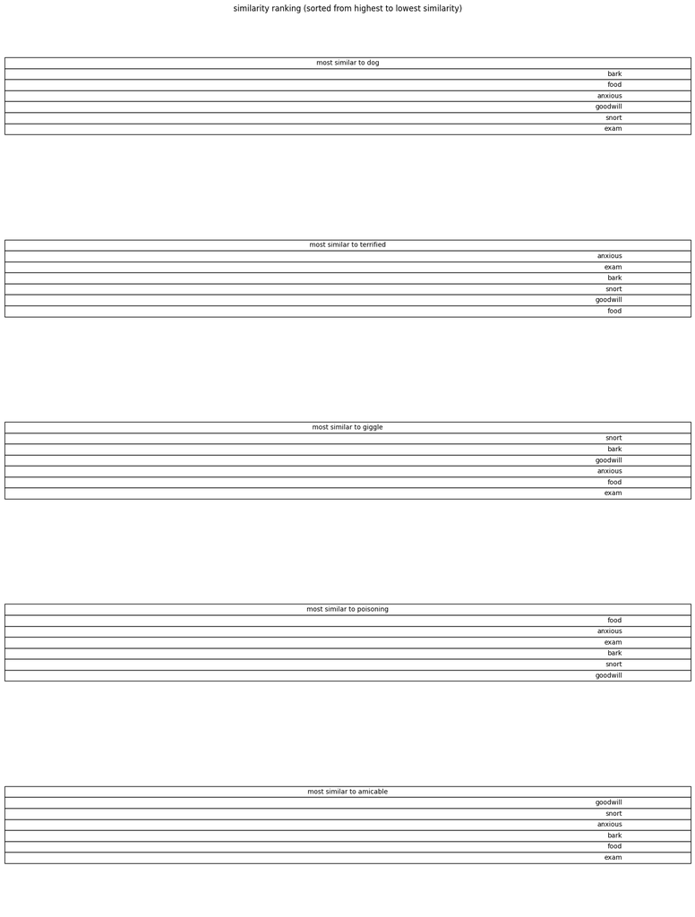

```
The computed similarities between source words (rows) and target words (columns) using cosine similarity:

                  bark   anxious  goodwill      food     snort      exam
0        dog  0.262555  0.080420  0.089756  0.338643  0.057631  0.001620
1  terrified  0.084213  0.515443 -0.104040  0.102032  0.096572  0.017092
2     giggle  0.227527  0.187366 -0.044279 -0.031313  0.407029  0.008178
3  poisoning  0.108921  0.028121  0.031326  0.288781  0.064294  0.093317
4   amicable -0.012938  0.158176  0.153692 -0.064875  0.048036 -0.123948
```

```python
# Calculating word-to-word similarities-----------------------------------------------------------------------------
def calc_cos_sim(vec_a, vec_b):
    cos_sim_score = (vec_a @ vec_b.T) / ((sum(vec_a**2)**(0.5)) * (sum(vec_b**2)**(0.5)))
    # print((vec_a @ vec_b.T) / (np.sqrt(np.sum(vec_a**2)) * np.sqrt(np.sum(vec_b**2))))
    return cos_sim_score

# select 5 arbritrary source words
src_words = ['dog', 'terrified', 'giggle', 'poisoning', 'amicable']

# select 6 target words that are somehow related to the source words or not at all
target_words = ['bark', 'anxious', 'goodwill', 'food', 'snort', 'exam']
# we reuse the target words for each of the source words to compute the degree of semantic relations

# our similarity estimation
import matplotlib.pyplot as plt
fig, ax = plt.subplots(5, figsize=(15,20))
fig.suptitle('similarity ranking (sorted from highest to lowest similarity)')
fig.patch.set_visible(False)
ax[0].axis('off')
ax[0].axis('tight')
ax[0].table(cellText=[['bark'],['food'],['anxious'],['goodwill'],['snort'],['exam']], colLabels=['most similar to dog'], loc='center')
ax[1].axis('off')
ax[1].axis('tight')
ax[1].table(cellText=[['anxious'],['exam'],['bark'],['snort'],['goodwill'],['food']], colLabels=['most similar to terrified'], loc='center')
ax[2].axis('off')
ax[2].axis('tight')
ax[2].table(cellText=[['snort'],['bark'],['goodwill'],['anxious'],['food'],['exam']], colLabels=['most similar to giggle'], loc='center')
ax[3].axis('off')
ax[3].axis('tight')
ax[3].table(cellText=[['food'],['anxious'],['exam'],['bark'],['snort'],['goodwill']], colLabels=['most similar to poisoning'], loc='center')
ax[4].axis('off')
ax[4].axis('tight')
ax[4].table(cellText=[['goodwill'],['snort'],['anxious'],['bark'],['food'],['exam']], colLabels=['most similar to amicable'], loc='center')
fig.tight_layout()
plt.show()

# compute cosine similarities
total_cos_sims = []
for src in src_words:
    cos_sims = []
    for target in target_words:
        cos_sims.append(calc_cos_sim(embeddings_dict[src], embeddings_dict[target]))
    total_cos_sims.append(np.array(cos_sims))

import pandas as pd
cos_sim_df = pd.DataFrame(np.array(total_cos_sims), columns=target_words)
cos_sim_df.insert(0, '', src_words, True)
print('\nThe computed similarities between source words (rows) and target words (columns) using cosine similarity:\n')
print(cos_sim_df)
```

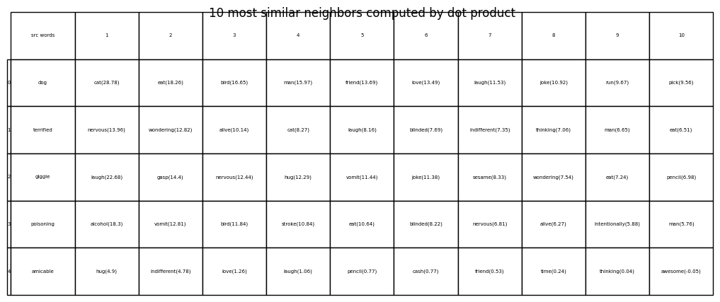

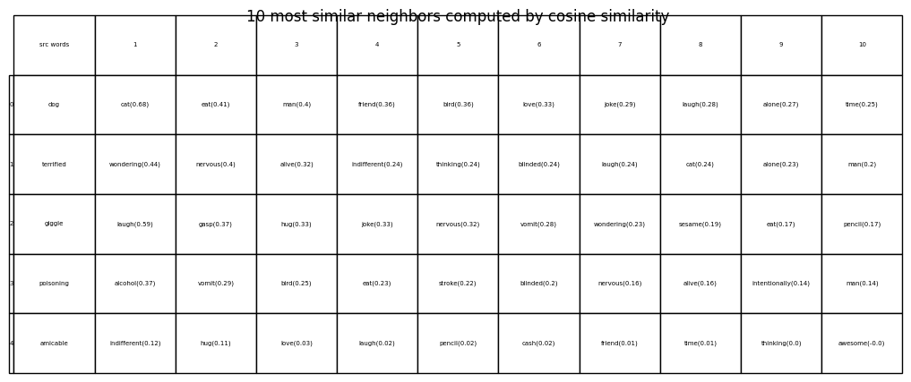

```python
# Calculating nearest neighbors-------------------------------------------------------------------------------------
word_dict = {
    0:'cat', 1:'cash', 2:'run', 3:'love', 4:'contemporary', 5:'indifferent',
        6:'laugh', 7:'gasp', 8:'vomit', 9:'man', 10:'alcohol', 11:'pencil', 12:'time',
        13:'friend', 14:'hug', 15:'joke', 16:'crouch', 17:'tapping', 18:'thinking',
        19:'blinded', 20:'pick', 21:'wondering', 22:'nervous', 23:'alone', 24:'eat',
        25:'alive', 26:'stroke', 27:'intentionally', 28:'bird', 29:'awesome', 30:'sesame'
}

def get_knn(src_vec, target_vecs, k=10, metric='cosine'):

    sim_scores = src_vec @ target_vecs.T
    if metric == 'cosine':
        denominator = (sum(src_vec**2))**(0.5)
        denominator *= (np.sum(target_vecs**2, axis=1))**(0.5)
        # print(np.sqrt(np.sum(src_vec**2)) * np.sqrt(np.sum(target_vecs**2, axis=1)))
        sim_scores /= denominator

    if k < len(sim_scores):
        max_ids = sorted(range(len(sim_scores)), key=sim_scores.__getitem__)[-k:]
        # print(np.argsort(sim_scores)[-k:])
        max_scores = sim_scores[max_ids]

    return max_ids[::-1], max_scores[::-1]

dot_knn = []
cos_knn = []
for src in src_words:
    target_vecs = [embeddings_dict[w] for w in word_dict.values()]
    ids, scores = get_knn(embeddings_dict[src], np.array(target_vecs).reshape(-1,300), k=10, metric='dot')
    dot_knn.append(np.array([word_dict[id_]+'('+str(np.round(score,2))+')' for id_, score in zip(ids, scores)]))
    ids, scores = get_knn(embeddings_dict[src], np.array(target_vecs).reshape(-1,300), k=10, metric='cosine')
    cos_knn.append(np.array([word_dict[id_]+'('+str(np.round(score,2))+')' for id_, score in zip(ids, scores)]))

dot_df = pd.DataFrame(np.array(dot_knn), columns=['1', '2', '3', '4', '5', '6', '7', '8', '9', '10'])
dot_df.insert(0, 'src words', src_words, True)

cos_df = pd.DataFrame(np.array(cos_knn), columns=['1', '2', '3', '4', '5', '6', '7', '8', '9', '10'])
cos_df.insert(0, 'src words', src_words, True)

fix, ax = plt.subplots()
ax.axis('off')
ax.set_title('10 most similar neighbors computed by dot product')
table = pd.plotting.table(ax, dot_df, loc='center', cellLoc='center')
table.scale(2,4)

fix, ax = plt.subplots()
ax.axis('off')
ax.set_title('10 most similar neighbors computed by cosine similarity')
table = pd.plotting.table(ax, cos_df, loc='center', cellLoc='center')
table.scale(2,4)
```

We would prefer the cosine similarity due to the fact that the results are far easier to interpret because of the normalization term. The score is a value between 0 and 1 (also in the negative direction). The closer to 1 the more similar the words are. The dot product returns numbers without normalization, so they are not in a particular range, and due to that somehow less meaningful.

## Task B: Document Classification with WE (15 points)

This task follows the same instruction for document classification as provided in Assignment 1. You are indeed free to reuse any part of your code in Assignment 1 for this task. In Assignment 1, the representation of each document was created using a bag of words representation followed by dimensionality reduction. In this task, the document representations are created from the pre-trained word embeddings.

**Map word embeddings to dictionary words (5 points).** For every word in the dictionary (as discussed and created in Assignment 1), fetch the corresponding word embedding from the pre-trained model. If no embedding is found, initialize the corresponding word embedding randomly.

**Document embedding as the average of word embeddings (5 points).** Using the word embeddings, the representation of each document is defined as the *mean of the vectors of each document's words*. In particular, given the document $d$, consisting of words $\left[ v_1, v_2, ..., v_{|d|} \right]$, the document representation $\mathbf{e}_d$ is defined as:

$\mathbf{e}_d = \frac{1}{|d|}\sum_{i=1}^{|d|}{\mathbf{e}_{v_i}}$

where $\mathbf{e}_{v}$ is the vector of the word $v$, and $|d|$ is the length of the document.

**Classification and evaluation (5 points)** Using these new document representations, apply three classification algorithms and report the evaluation results (based on accuracy metric) on the test set.

```python
# reuse the code from Assignment 1-----------------------------------------------------------------------------------

import os
import glob
import re
import itertools
import pandas as pd
import numpy as np
import nltk
from nltk.tokenize import MWETokenizer
from nltk.stem import WordNetLemmatizer, PorterStemmer
from nltk.corpus import stopwords
from collections import Counter

def split_into_texts_and_labels(data):
    labels = []
    texts = data.split('\n')
    texts = [text for text in texts if len(text)>0]
    for i, text in enumerate(texts):
        try:
            nr = int(text[-1])
            labels.append(text[-1])
            texts[i] = ''.join(list(text)[:-2])
        except:
            break
    return texts, labels

def perform_basic_preprocessing(text):
    text = text.lower()

    for d in re.finditer('\d{1,2}[/-]\d{1,2}[/-]\d{2,4}', text):
        text = text.replace(str(d.group()), '<date>')

    for d in re.finditer(r'(\d{1,2}[\s]?|\d{1,2}[\s]?th[\s]?)?(?:january|february|march|april|may|june|july|august|september|october|november|december|jan|feb|mar|apr|may|jun|jul|aug|sep|oct|nov|dec)[\s-]?(\d{1,2})?[,\s-]?[\s]?\d{4}', text, re.I|re.M):
        text = text.replace(str(d.group()), '<date>')

    for d in re.finditer(r'(\d{1,2}|\d{1,2}[\s]?th)[\s]?(?:january|february|march|april|may|june|july|august|september|october|november|december|jan|feb|mar|apr|may|jun|jul|aug|sep|oct|nov|dec)', text, re.I|re.M):
        text = text.replace(str(d.group()), '<date>')

    for d in re.finditer(r'\d{1,2}[/-]\d{4}', text, re.M|re.I):
        text = text.replace(str(d.group()), '<date>')

    text = re.sub('[0-9]*[[,.]?[0-9]+]*', '<num>', text)

    text = re.sub('([^a-z<>])+', ' ', text)

    return text

def perform_tokenization(text):
    stop_words = set(stopwords.words('english'))
    lemmatizer = WordNetLemmatizer()

    tokenizer = MWETokenizer([('<', 'num', '>'), ('<', 'date', '>')])
    tokens = tokenizer.tokenize(nltk.word_tokenize(text))

    tokens = [token for token in tokens if not token in stop_words]
    tokens = [lemmatizer.lemmatize(token) for token in tokens]
    return tokens


files = glob.glob(os.path.join('nlp2023_24_data', '**', '*'))

for file in files:
    if os.path.basename(file).__contains__('train'):
        with open(file, 'r') as fh:
            train_data = fh.read()
    elif os.path.basename(file).__contains__('test'):
        with open(file, 'r') as fh:
            test_data = fh.read()
    elif os.path.basename(file).__contains__('validation'):
        with open(file, 'r') as fh:
            val_data = fh.read()
    elif os.path.basename(file).__contains__('labels'):
        with open(file, 'r') as fh:
            labels = fh.read()

train_texts, train_labels = split_into_texts_and_labels(train_data)
val_texts, val_labels = split_into_texts_and_labels(val_data)
test_texts, test_labels = split_into_texts_and_labels(test_data)

tokens_per_text_train = []
for text in train_texts:
    tokens_per_text_train.append(perform_tokenization(perform_basic_preprocessing(text)))

word_dict = dict(Counter(list(itertools.chain(*tokens_per_text_train))))
word_dict = dict(sorted(word_dict.items(), key=lambda x:x[1], reverse=True))

threshold = 100
smaller_word_dict = {k:v for (k,v) in word_dict.items() if v > threshold}
```

```python
# Map word embeddings to dictionary words--------------------------------------------------------------------------

# word_embeddings = dict((k,embeddings_dict[k]) if k in embeddings_dict else (k,np.random.randn(300)) for (k,v) in smaller_word_dict.items())
word_embeddings = dict()
for (k,v) in smaller_word_dict.items():
    if k in embeddings_dict:
        word_embeddings[k] = embeddings_dict[k]
    else:
        word_embeddings[k] = np.random.randn(300)
```

```python
# Document embedding as the average of word embeddings--------------------------------------------------------------

def get_doc_repr(doc, word_embeddings):
    tokens = perform_tokenization(perform_basic_preprocessing(doc))
    # remove Nones, does happen if the token is not in the dictionary, just ignore the token
    tokens = [token for token in tokens if token in smaller_word_dict]
    # get the embeddings of the tokens and calculate an average embedding
    e_d = np.sum(list(map(word_embeddings.get, tokens)), axis=0) / len(tokens)
    return e_d
```

```python
# Classification and evaluation-------------------------------------------------------------------------------------

from sklearn.svm import SVC
from sklearn.metrics import accuracy_score
from sklearn.ensemble import RandomForestClassifier, AdaBoostClassifier

train_data = []
for text in train_texts:
    train_data.append(get_doc_repr(text, word_embeddings))
train_mtr = pd.DataFrame(train_data.copy()).to_numpy()
train_labels = np.array(train_labels).astype('int')

val_data = []
for text in val_texts:
    val_data.append(get_doc_repr(text, word_embeddings))
val_mtr = pd.DataFrame(val_data.copy()).to_numpy()
val_labels = np.array(val_labels).astype('int')

# first classifier - SVC
kernels = ['linear', 'poly', 'rbf']
max_acc_val_svc = 0
best_hyperparam = ''
for kernel in kernels:
    svc = SVC(kernel=kernel).fit(train_mtr, train_labels)
    preds = svc.predict(val_mtr)
    acc = accuracy_score(val_labels, preds.astype('int'))
    if acc > max_acc_val_svc:
        max_acc_val_svc = acc
        best_hyperparam = kernel

print(f'Max accuracy: {max_acc_val_svc} for SVC with {best_hyperparam}-kernel')
```

```
Max accuracy: 0.7931432973805855 for SVC with linear-kernel
```

```python
# second classifier - RFC
n_estimators = [10, 50, 100, 250, 500]
max_acc_val_rfc = 0
best_hyperparam = ''
for est in n_estimators:
    rfc = RandomForestClassifier(n_estimators=est).fit(train_mtr, train_labels)
    preds = rfc.predict(val_mtr)
    acc = accuracy_score(val_labels, preds.astype('int'))
    if acc > max_acc_val_rfc:
        max_acc_val_rfc = acc
        best_hyperparam = est

print(f'Max accuracy: {max_acc_val_rfc} for RFC with {best_hyperparam} estimators')
```

```
Max accuracy: 0.7280431432973806 for RFC with 500 estimators
```

```python
# third classifier - AdaBoost
# could also vary learning rate
n_estimators = [10, 50, 100, 250]
max_acc_val_abc = 0
best_hyperparam = ''
for est in n_estimators:
    abc = AdaBoostClassifier(n_estimators=est).fit(train_mtr, train_labels)
    preds = abc.predict(val_mtr)
    acc = accuracy_score(val_labels, preds.astype('int'))
    if acc > max_acc_val_abc:
        max_acc_val_abc = acc
        best_hyperparam = est

print(f'Max accuracy: {max_acc_val_abc} for AdaBoostClassifier with {best_hyperparam} estimators')
```

```
Max accuracy: 0.6167180277349769 for AdaBoostClassifier with 250 estimators
```

```python
# for each of the three classifiers pick the one with the best hyperparameter setting and evaluate on the test set
test_data = []
for text in test_texts:
    test_data.append(get_doc_repr(text, word_embeddings))
test_mtr = pd.DataFrame(test_data.copy()).to_numpy()
test_labels = np.array(test_labels).astype('int')

classifiers = [SVC(kernel='linear'), RandomForestClassifier(n_estimators=500), AdaBoostClassifier(n_estimators=250)]
for c in classifiers:
    model = c.fit(train_mtr, train_labels)
    preds = model.predict(test_mtr)
    acc = accuracy_score(test_labels, preds.astype('int'))
    print(f'Classifier: {c} with accuracy: {acc}')
```

```
Classifier: SVC(kernel='linear') with accuracy: 0.778805394990366
Classifier: RandomForestClassifier(n_estimators=500) with accuracy: 0.7321772639691715
Classifier: AdaBoostClassifier(n_estimators=250) with accuracy: 0.6227360308285164
```

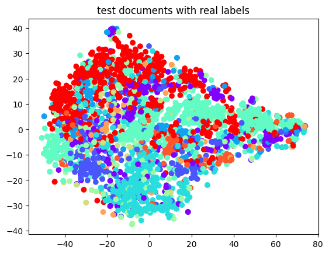

```python
# plot the real test labels
mtr_embedded = TSNE(n_components=2).fit_transform(test_mtr)
colormap = plt.cm.rainbow(np.linspace(0, 1, 10))
plt.scatter(mtr_embedded[:, 0], mtr_embedded[:, 1], c=colormap[np.array(test_labels).astype('int')])
plt.title('test documents with real labels')
plt.show()
```

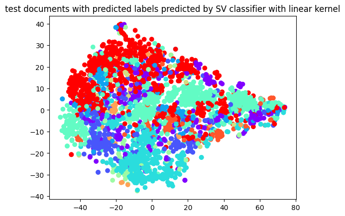

```python
# plot the classification results of the best classifier
svc = SVC(kernel='linear').fit(train_mtr, train_labels)
preds = svc.predict(test_mtr)
colormap = plt.cm.rainbow(np.linspace(0, 1, 10))
plt.scatter(mtr_embedded[:, 0], mtr_embedded[:, 1], c=colormap[np.array(preds).astype('int')])
plt.title('test documents with predicted labels predicted by SV classifier with linear kernel')
plt.show()
```

## Task C: Classification with sent2vec Document Embeddings (2 extra point)

Sent2vec [1] suggests another unsupervised approach to creating document embeddings from the underlying word embeddings. First, using the provided code in the paper, train a sendtvec model on the training set to create document embeddings. Then, repeat Task B while using the document embeddings provided by sent2vec. Similar to Task 2, conduct the classification experiments and report evaluation results.

[1] M. Pagliardini, P. Gupta, and M. Jaggi. Unsupervised Learning of Sentence Embeddings using Compositional n-Gram Features. In Proceedings of the conference of the North American Chapter of the Association for Computational Linguistics (NAACL), 2018.

```python
# train a sent2vec model on the training set to create document embeddings
```